# Inference part II: t tests and inference in regression

# Introduction

This week we’ll look at **inference for continuous variables** and how to analyse them in R. We’ll cover:

- One sample t-test
- Two sample/ independent sample t test
- Inference in our regression output

# R’s family of distribution functions: comparing the normal and t distributions

Last week we saw how to use the various `binom` functions, including `rbinom` to get random draws from the binomial distribution, `dbinom` to get the probability of an event on the binomial distribution and `pbinom` to get the sum of probabilities under the curve.

R uses different versions of the same thing for other distributions. Let’s compare the t and normal distributions to see how each works.

We’ll sample from each of them and compare. Recall from the lecture:

- The point of the t distribution is: it can account for extra uncertainty when sample size is low. (It has longer tails when sample size is low.)
- The t distribution’s only variable is **degrees of freedom**: for our tests here, that’s just **sample size minus one**
- The t distibution becomes like the normal distribution as sample size grows - they become close very quickly
- The normal distribution only needs two numbers: the **mean** and **standard deviation**

Let’s get some random samples from each and plot them over each other to see what difference sample size makes. Start with 3 degrees of freedom for a t distribution, equivalent to modelling a sample size of 4.

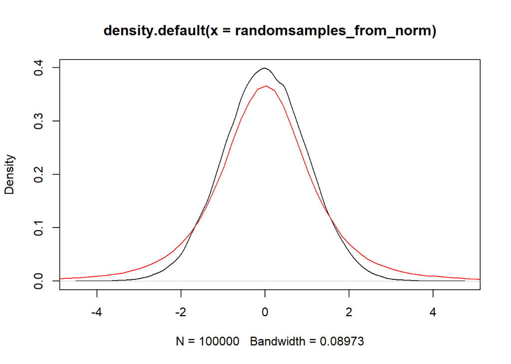

```r
randomsamples_from_t <- rt(n = 100000, df = 3)

randomsamples_from_norm <- rnorm(n = 100000, mean = 0, sd = 1)

plot(density(randomsamples_from_norm))
lines(density(randomsamples_from_t), col='red')
```

> **EXERCISE: Change the t distibution’s df argument (degrees of freedom) to see how quickly it starts to match the normal distribution’s shape. Try 10 then 100.**

# One-sample t test: do this class’ student grades differ from the regional average

This example is based on one from Danielle Navarro’s online book, which you can read at [learningstatisticswithr.com/book](https://learningstatisticswithr.com/book/). If you want to properly understand t tests I’d highly recommend reading those sections.

for the first t-test, let’s repeat the analysis from the lecture. We’re doing the following:

- Loading in 20 (fictional) student grades from a (fictional) class
- Asking: do these grades differ from the (fictional) regional average for the same subject?

Let’s load in the data first. I’ve included the actual numbers in vector form, but you can just load in via URL. Also, we’ll check the mean and standard deviation for the grades.

We’ll also set our fictional regional grade and assign to an object called `meanofpopulation`;

```r
#Type in manually...
grades <- c(50,60,60,64,66,66,67,69,70,74,76,76,77,79,79,79,81,82,82,89)

#Or load them from the interwebnets
grades <- readRDS(url('https://bit.ly/smi106grades'))

mean(grades)
```

```
## [1] 72.3
```

```r
sd(grades)
```

```
## [1] 9.520615
```

```r
#Assumption of all class's grades
meanofpopulation <- 67.5
```

So we can **see that the class and regional grades differ**, but is the class grade really different from the regional grade? Can we be 95% sure? Our **null hypothesis** here is:

- There is **no difference** between class and regional grade, or to put it another way;
- The class and regional grades come from the same distribution

The way we’re going to check this is as follows - it’s same basic idea as with Paul the Octopus’ guesses:

- If we subtract the regional mean from the grade mean to get the **difference**
- We then want to know how likely it is that **mean difference** could have come from the null distribution for that sample size
- To repeat: that null distribution is our representation of the idea that (a) the class grades and population grades could have come from the same pool of grades and (b) the sample size is 20, so we know there’s going to be **sampling error**, if we resampled many times
- If there was really no difference, repeated samples would have error that clustered around zero, and had some spread either side of zero

As covered in the lecture, there’s an extra step we take here to make it easier to reject the null:

- Our **mean difference** is **standardised**, in just the way we did with z-scores - except with a tweak for sample size because we’re standardising to the t distribution
- We can then compare this standardised value to the t distribution directly, to see if we can reject the null
- I’ll go over this point again in a second when we have a value, just to try and be doubly clear on what’s happening

So, we’ll:

- Compare our actual sample estimate with the t distribution we’d get if there was **no difference** in our two means.

Let’s do that manually to start with, so we can see the process, before getting R to do the work for us.

First, we know that:

- If the null were true, and the class mean and regional mean were from the **same** distribution
- And we had a sample of 20 from that, as we do here
- Then we could see the shape of the assumed t distribution by **just inputting the sample number minus one as the degrees of freedom**, just as we did.

Let’s see this by getting enough random samples from the t distribution to plot it, as we just did (though including a histogram of the values too):

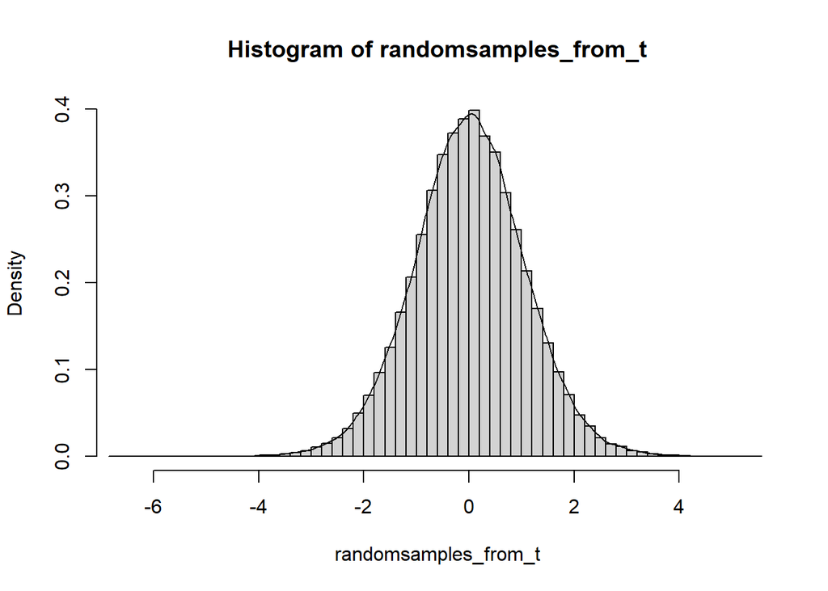

```r
randomsamples_from_t <- rt(n = 100000, df = length(grades)-1)

hist(randomsamples_from_t, breaks = 50, freq=F)
lines(density(randomsamples_from_t))
```

Now all we need to do is **standardise our difference between the class and regional mean** so we know what its position on the t distribution would be. We saw the maths for that in the lecture, it’s pretty straightforward. Symbols include:

- $\bar{x}$ (“x-bar”) is the mean for our class grades
- $\mu$ (“mu”) is the mean from the region
- $\hat{\sigma}$ (“sigma-hat”) is our sample standard deviation (wearing a hat to distinguish it from the population standard deviation, that we don’t know and can’t know.)

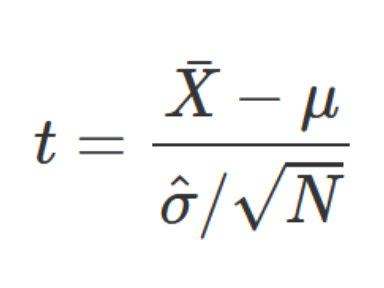

OK, let’s use that formula to **calculate our t value**. We’ll break it down into parts to make it more readable, but you could of course code this all in one. (I find it’s generally good practice to break things down so it’s easier for **me** to read the code.)

```r
numerator <- mean(grades) - meanofpopulation

denominator <- sd(grades)/sqrt(length(grades))

t <- numerator/denominator

t
```

```
## [1] 2.254713
```

So - **where does this t value sit on the t distribution?** Let’s add it to graphic we made before. We’ll rerun all the code together, first getting more random samples from the t distribution, for the number of samples we have for our class grades.

We’ll call our random samples from t `null` this time, so we know we’re referring to **what we’d get if we repeatedly sampled from the null t distribution 20 twenty times over and over**:

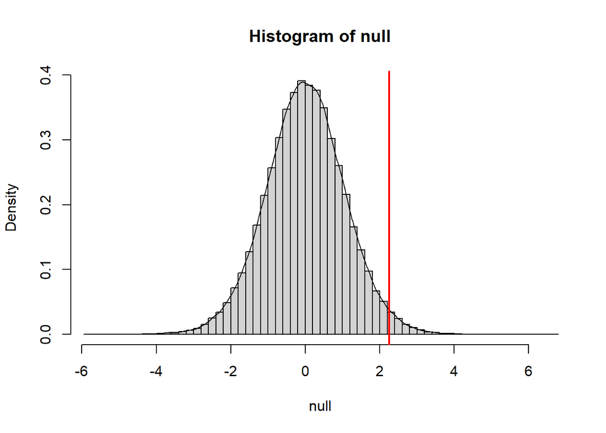

```r
null <- rt(100000, df = length(grades)-1)

hist(null, breaks = 50, freq=F)
lines(density(null))

#Add our calculated t value
abline(v = t, lwd = 2, col='red')
```

Looking pretty far on the right side of the distribution. How far? **What’s the probability of getting something more extreme than this value?**

As before we can either **actually count the number of observations, as if we’d repeat-sampled from the underlying distribution:**

```r
mean(null > t)
```

```
## [1] 0.01839
```

- So p = 0.01839: **a 1.839% probability that, if there was *no difference* between the class grade mean and the regional (population) mean, you could get the value we did get, having taken 20 samples from the underlying data.**

> **Let’s just run through what just happened again one more time.**
1. We did exactly the same thing as with Paul the Octopus. There, we saw how unlikely Paul’s 12 out of 14 football matches guesses would be, if the data was no better than random coin flips:

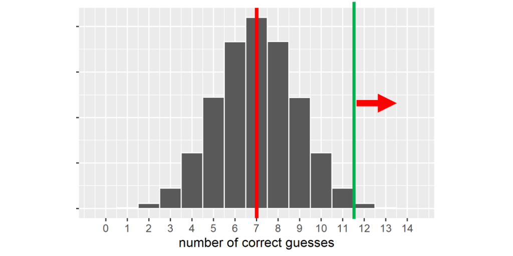

2. We are asking whether the grade mean differs from some ‘population’ mean, in this the grade average in the wider region. To do this, we’re asking, “if they did **not** differ, if they came from the same underlying distribution, and we resampled many times from it - 20 samples each time - how likely would it be to get the value we **did** get.”

There’s **another key step here though**. We could have done this by looking at the actual distribution of differences in means, which looks like this, with the actual grade mean on the distribution:

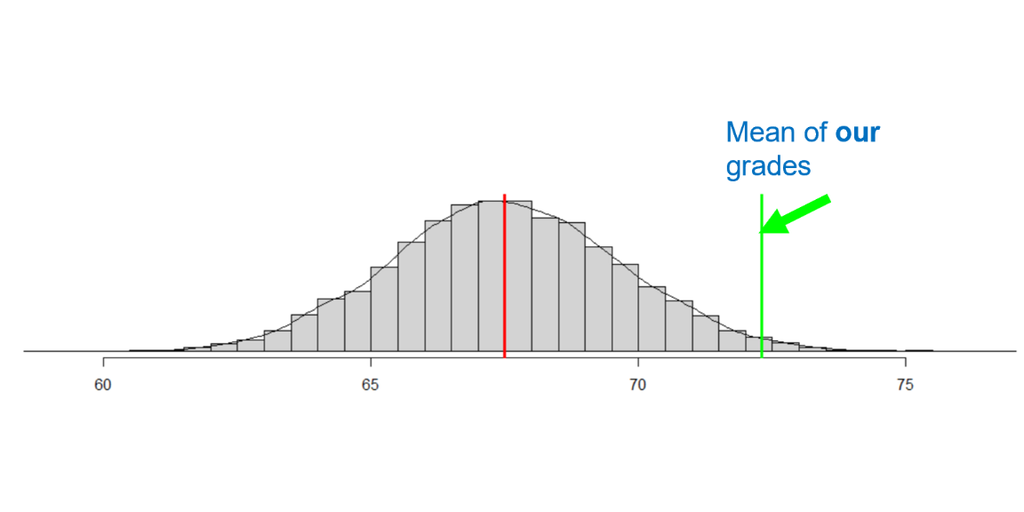

But instead we took the extra step of **standardising the grade mean so it fits on a *standard* t distribution**:

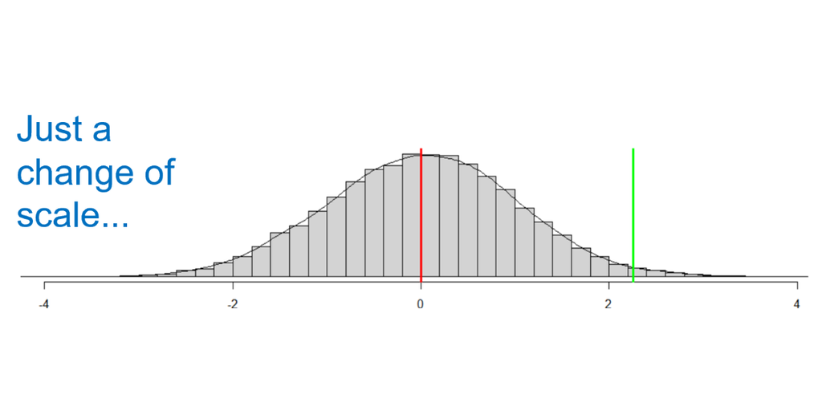

But: **this is just a rescaling.** It makes it easier to compare to the base distribution to reject the null, but it’s doing precisely the same thing as we saw with Paul the Octopus (though with the a different distribution), and with the non-rescaled version.

> **Our p value above was *one-tailed*: it told us the probability of getting a value *more* than our mean difference, if the data came from the null. But we probably want a *two-tailed test* here: we want to know whether we could get something as extreme as our grades *on either side of the distribution*, positive or negative.**

We *could* work out the probability of both tails and sum them. Or just **multiply by two** (because the distribution’s symmetric, both tails contain the same probability.)

```r
mean(null > t) * 2
```

```
## [1] 0.03678
```

And, as with `pbinom`, we could also use R’s mathematical version of the distribution to get a more precise value if we wanted (you’ll see this more accurately matches R’s `t.test` p value below.)

```r
pt(q = t, df = length(grades)-1, lower.tail = F) * 2
```

```
## [1] 0.03614522
```

## The R code version of the one-sample grades comparison

Getting R to run that for us is simple:

1. Add the grades data
2. Set $\mu$ mu, which is the population mean we want to compare to (the regional grade mean in this case).

```r
#Our manually calculated t value
t
```

```
## [1] 2.254713
```

```r
#Our manually calculated two-tailed p value
pt(q = t, df = length(grades)-1, lower.tail = F) * 2
```

```
## [1] 0.03614522
```

```r
#Getting R to run the t test
t.test(grades, mu = 67.5)
```

```
##
##  One Sample t-test
##
## data:  grades
## t = 2.2547, df = 19, p-value = 0.03615
## alternative hypothesis: true mean is not equal to 67.5
## 95 percent confidence interval:
##  67.84422 76.75578
## sample estimates:
## mean of x
##      72.3
```

# Two sample t tests

In this section, we’ll **use a t test to compare the means from two different samples**. The principles are very similar to the test we just did - the only differences here will be:

- we’ll use an **altered equation to work out the standardised t value**.
- The output from the t test this time will show us the **difference in means** e.g. in its confidence intervals

First, let’s load the data we’ll use - **the same height and weight data** we’ve used before, with a couple of additions:

1. A binary variable for “earnings above $16,000” (which was the median earnings when this dataset was collected)
2. A binary variable for “angry or not”

```r
df <- read.csv(url('https://bit.ly/smi106ttest'))
```

> We’ll start off by asking: **are angry people shorter than non-angry people?** (Which is a *directional question*, so we can use a one-tailed test.)
- **Note: I am unsure what this `angry` variable is really referring to, but this is a fun/silly example to work with, so let’s stick with it…**

And again we’ll work out our t-value and null distribution **manually** to begin with, before seeing how to stick it all in the `t.test` function.

> **Note: doing this manually can actually be very useful for making sure you know exactly what it is you’re asking the test to tell you. I find it useful e.g. in this kind of case, where I need to know what polarity I’m after.** Otherwise just running the t-test can be a little confusing.

**Here’s the equation to find our t value**, this time for the two-sample t-test. Note: this is for what’s called a **Welch two sample t-test** - which R uses by default. This just means we **don’t assume the two samples have the same variance / the same spread of data around their means**. Assuming anything else is a strong assumption, so this way’s better.

The equation contains:

- $\bar{x}_1 - \bar{x}_2$: so that’s just the mean of sample 1 minus the mean of sample 2. If it’s zero, there’s **no difference between them**
- The denominator’s similar to before - except **this time it’s got the standard deviation for each sample separately, and the sample size for each separately too.**

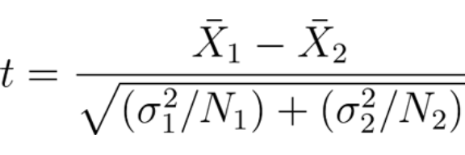

To make things a bit easier for us, let’s **subset the data to angry and non-angry people**, so we can work with each a bit more tidily.

Note, we’re making a subset of the **whole dataframe**, so the logical operator is **applying only to the rows in the first index**, followed by a comma for **“give me all the columns”**.

- **Be sure to use `angry_or_not`, which is a binary variable, not `angry` (which contains seven levels).**

```r
angry <- df[df$angry_or_not==1,]

notangry <- df[df$angry_or_not==0,]
```

Before we find the t value, can we see any difference in height means between these two?

```r
mean(angry$height)
```

```
## [1] 66.34286
```

```r
mean(notangry$height)
```

```
## [1] 66.79307
```

```r
#Subtracting them to see the difference
mean(notangry$height) - mean(angry$height)
```

```
## [1] 0.4502112
```

It looks like angry people are -0.4502112 inches **shorter**. Is is statistically significant? Let’s use a t test.

Breaking down the t value calculation, that looks like the following. We’ll:

- Break it down into a numerator
- And two denominator parts
- Before combining

Note also:

- The effect of the order of the subtraction:
- Heights of angry people minus heights of not-angry people:
- If it’s positive, angry people are taller;
- If it’s negative, angry people are shorter

```r
numerator <- (mean(angry$height) - mean(notangry$height))

denominator1 <- sd(angry$height)^2/length(angry$height)
denominator2 <- sd(notangry$height)^2/length(notangry$height)

t <- numerator/sqrt(denominator1 + denominator2)
```

**Note: because of the way round we’re finding the differences, the t value comes out as negative. That’s fine, it’s what we need in this case.**

We have to **make a new null t distribution to compare this to** because the sample sizes are much bigger. Note, we compare to **both sample sizes combined**. We’ll make those separately to keep the code tidy.

```r
samplesize <- length(angry$height) + length(notangry$height)

null <- rt(100000, df = samplesize - 1)
```

Now we can work out our one-tailed p value: **if there was no difference between the two means, and the sample size was 1786, how likely is it we’d see a different in heights *less than* the one we do see?**

```r
mean(null < t)
```

```
## [1] 0.00639
```

And of course, we could find the same thing (slightly more precisely) using `pt` to find the area under the probability curve. Here, we **do** want to find this for the lower tail, not the upper.

```r
pt(q = t, df = samplesize -1, lower.tail = TRUE)
```

```
## [1] 0.00646903
```

So that’s telling us:

- **If these two samples came from the same distribution, we could expect to see it showing the value we got for shorter people being angrier 0.646903% of the time, if the sampling were repeated.**
- So at, say a p value level of p < 0.05, we ** *can* reject the null that the mean difference we find comes from the same distribution.**

Let’s run that using R’s `t.test` function as well. The only difference here:

- We’re entering each of the samples, where before we entered one sample and a mu value for the assumed population mean.
- We can also tell the `t.test` that we want a particular tail. `alternative = 'less'` tells it to use the lower tail.

```r
t.test(angry$height, notangry$height, alternative = 'less')
```

```
##
##  Welch Two Sample t-test
##
## data:  angry$height and notangry$height
## t = -2.488, df = 1756.1, p-value = 0.00647
## alternative hypothesis: true difference in means is less than 0
## 95 percent confidence interval:
##        -Inf -0.1524093
## sample estimates:
## mean of x mean of y
##  66.34286  66.79307
```

Though if we tell it which tail to use, we don’t get very useful confidence intervals. So we could just **leave alternative blank, and halve the p-value if we want a one-tailed test**:

```r
t.test(angry$height, notangry$height)
```

```
##
##  Welch Two Sample t-test
##
## data:  angry$height and notangry$height
## t = -2.488, df = 1756.1, p-value = 0.01294
## alternative hypothesis: true difference in means is not equal to 0
## 95 percent confidence interval:
##  -0.80512140 -0.09530091
## sample estimates:
## mean of x mean of y
##  66.34286  66.79307
```

As always - the p value and confidence intervals are two sides of the same coin:

- The p value tells us we can reject the null (assuming we decided our p cutoff was p < 0.05)
- The 95% confidence interval **does not include zero**, so the model is ruling out the difference in means being above or below zero.

## Visualising a t-test with the `dabestr` package

One quick way to **see** what a t-test is showing is to use the `dabestr` package. Let’s install it, and any dependencies. You can install in the usual way:

```r
install.packages('dabestr')
```

Then load the library:

```r
library(dabestr)
```

> **Note: loading the library may not work as there may be some missing dependencies that will also need to be installed. Try it, and we’ll look to see what libraries are missing.**

Once installed, we can use it to visualise our angry / not-angry / height data. Note though:

- **dabestr takes in the full dataframe, and we just specify the data column (`height`) and the category column (`angry_or_not`).**
- **It may take a little while to run as it’s using bootstrapping simulation to get its results**.
- (We won’t cover bootstrapping in this module: for now, just note it’s a way to use simulation to work out confidence intervals and other inferential stats.)

```r
# The idx below passes "Control" as the control group,
# and "Group1" as the test group. The mean difference
# will be computed as mean(Group1) - mean(Control1).
two.group.unpaired <- dabest(df, angry_or_not, height,
         idx = c("0", "1"),
         paired = FALSE)

two.group.unpaired.meandiff <- mean_diff(two.group.unpaired)

# Calling the above object produces a textual summary of the computed effect size.
two.group.unpaired.meandiff
```

```
## dabestr (Data Analysis with Bootstrap Estimation in R) v0.3.0
## =============================================================
##
## Good evening!
## The current time is 12:40 PM on Thursday November 18, 2021.
##
## Dataset    :  df
## X Variable :  angry_or_not
## Y Variable :  height
##
## Unpaired mean difference of 1 (n = 805) minus 0 (n = 981)
##  -0.45 [95CI  -0.795; -0.0863]
##
##
## 5000 bootstrap resamples.
## All confidence intervals are bias-corrected and accelerated.
```

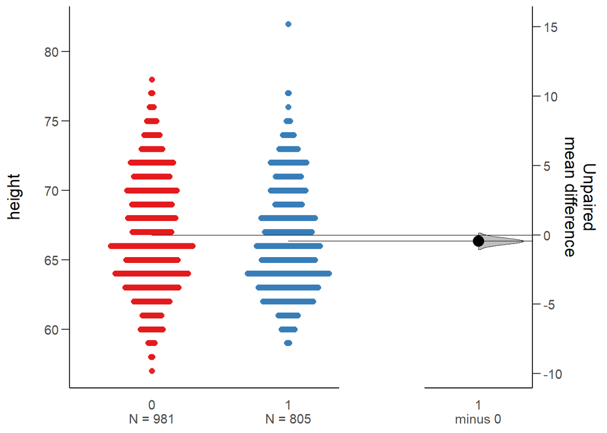

```r
#Make the plot
plot(two.group.unpaired.meandiff)
```

A few things to note there:

- The output from `two.group.unpaired.meandiff`:
- The confidence intervals are similar to the `t.test` above, though slightly different because bootstrapped.)
- The graphic makes it a little difficult to see if there’s a difference - because the difference is very small relative to the spread of the data. **In combination with how close the upper bound of the confidence intervals are to zero, this is suggesting a small effect size.**

> **EXERCISE: OK, time to have a go at a two-sample t-test yourself, using the same data. What we want to know: do earnings make a different to how tall you are? The `height` variable, remember, has inches as its units.**
- The dataset has a binary variable `earningsearnsabove16k`, which roughly splits the data into two equal halves
- First, subset the data into those two earnings groups (assigning to variables called something like `above16k` and `below16k`)
- Find the mean difference in height between those two earnings groups - which group is taller? Does it seem like a big difference?
- Then use a `t.test` to ask: **is there a significant difference in height for the two earnings groups?**

> **EXERCISE: Repeat the `dabestr` confidence interval-finding and visualisation for this data.** That’s just swapping out `angry_or_not` for `earnsabove16k`.

**Is it a larger effect size than `angry_or_not`?**

# The full regression output from R

Lastly, let’s look at the **full summary output from a simple regression model** so we can see how to make inference readings from it, and how to easily access confidence intervals.

We’ll re-use the same data we’ve just been using.

A sometimes useful function is `attach`: if we `attach` a dataframe, we no longer have to use its full name (such as `df$height`) but can instead just use `height`.

It’s not great if you’re working with many dataframes that may have matching column names, but it sometimes helps keep things tidy. Let’s do that for our current data.

```r
attach(df)
x <- lm(weight ~ height + age + male)

summary(x)
```

```
##
## Call:
## lm(formula = weight ~ height + age + male)
##
## Residuals:
##     Min      1Q  Median      3Q     Max
## -91.905 -18.477  -4.749  11.608 185.366
##
## Coefficients:
##               Estimate Std. Error t value Pr(>|t|)
## (Intercept) -136.67906   16.31765  -8.376  < 2e-16 ***
## height         4.12922    0.24802  16.649  < 2e-16 ***
## age            0.32030    0.03913   8.186 5.09e-16 ***
## male          11.13628    1.94909   5.714 1.29e-08 ***
## ---
## Signif. codes:  0 '***' 0.001 '**' 0.01 '*' 0.05 '.' 0.1 ' ' 1
##
## Residual standard error: 28.11 on 1782 degrees of freedom
## Multiple R-squared:  0.3389, Adjusted R-squared:  0.3378
## F-statistic: 304.5 on 3 and 1782 DF,  p-value: < 2.2e-16
```

> **I’ll run back through all the elements of this in the lecture slides, to remind us.**

> **There’s a handy function for getting confidence intervals for all our model coefficients:**

```r
confint(x)
```

```
##                   2.5 %       97.5 %
## (Intercept) -168.682811 -104.6753115
## height         3.642782    4.6156589
## age            0.243557    0.3970406
## male           7.313542   14.9590121
```

By default it outputs **95% confidence intervals**, but we can also set our own:

```r
confint(x, level = 0.99)
```

```
##                    0.5 %      99.5 %
## (Intercept) -178.7556169 -94.6025061
## height         3.4896816   4.7687597
## age            0.2194034   0.4211942
## male           6.1103808  16.1621732
```

Note what happens there when we increase the value of the confidence interval: **the intervals get wider**, as they have to cover more data to be 99% sure the true parameter is within its bounds.

## Visualising regression coefficients

We’ll look at ways to output regression tables another time, but today let’s stick to **visualising coefficients**.

There are a few options for plotting, but a quick one is to use the `jtools` library. Again, **install this library first**:

```r
install.packages('jtools')
```

Then load the library:

```r
library(jtools)
```

Then it’s just a simple case of dropping our model (assigned to `x` earlier) into `jtools`. Note, we’re also:

- Choosing a colour palette for it
- Setting the confidence intervals to 0.99

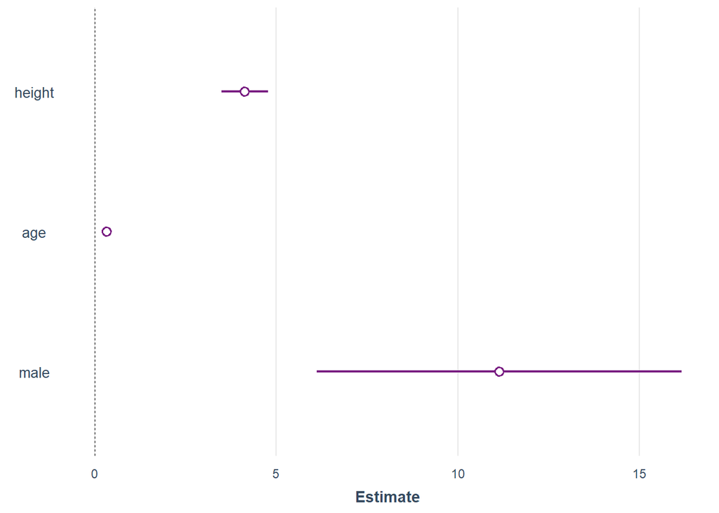

```r
jtools::plot_coefs(x,ci_level = .99, colors = "Rainbow")
```

We can see that `age` doesn’t show up very well, so we could transform it, so it becomes in units of 10 years.

> **EXERCISE: Have a go at doing this yourself. Transform the `age` variable - creating a new one in the `df` dataframe called something like `age_tenyears` by (a) dividing `df$age` by ten and assigning to a new column in `df`. You’ll then need to re-attach `df` if you want to use just plain column names as before. Then (b) re-run the `lm` model to include the new variable and (c) visualise the coefficients again with jtools.**

Let’s also quickly look at how to output someting similar using **ggplot**, so you can use all the control you have with `ggplot`, if you want to change anything yourself. We have a few steps to do.

1. Make a dataframe with the **regression coefficients** and the **confidence intervals**, so we can use that in `ggplot`
2. Use ggplot’s `geom_errorbar` function to add confidence intervals to the plot

First - making the dataframe:

1. We make a column for the `coefficients`
2. We `cbind` (column bind) this to the confidence intervals, just using the `confint` function we used before.
3. We add the **coefficient names in** to the data frame so `ggplot` can use them.

```r
df.viz <- data.frame(coefficients = x$coefficients)

df.viz <- cbind(
  df.viz,
  confint(x)
)

df.viz$names = row.names(df.viz)
```

Lastly, we **drop the intercept row** as we don’t want to visualise that:

```r
df.viz <- df.viz[-1,]
```

Take a look at the resulting dataframe before we use it to plot. It’s got everything together:

```r
df.viz
```

|  | coefficients | 2.5 % | 97.5 % | names |
| --- | --- | --- | --- | --- |
| height | 4.1292207 | 3.642782 | 4.6156589 | height |
| age | 0.3202988 | 0.243557 | 0.3970406 | age |
| male | 11.1362770 | 7.313542 | 14.9590121 | male |

Now we can use `ggplot` to plot our coefficients and the error bars around them. We’ll also need to **load the tidyverse.**

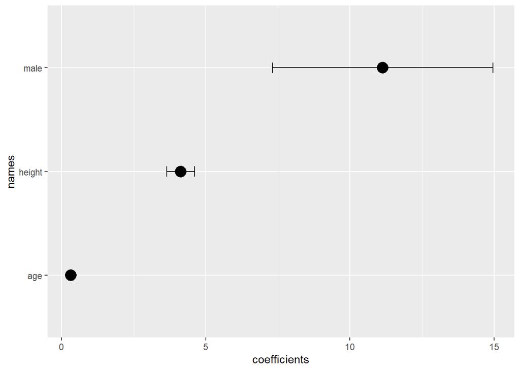

```r
library(tidyverse)

ggplot(df.viz, aes(y = coefficients, x = names)) +
  geom_point(size = 5) +
  geom_errorbar(aes(ymin = `2.5 %`, ymax = `97.5 %`), width = 0.1) +
  coord_flip()
```